# Project 1: Biomedical & Clinical Informatics

# 4 Assessing Multicollinearity & Feature Redundancy

As we finally, finally wrap-up pre-processing there is one final assessment we need to perform: **multicollinearity**. As I am certain you recall, multicollinearity is when we have high correlation between predictors (so much so, in fact, that it comes at the cost of any correlation with the target!). Recall from lecture that multicollinearity is when one or more of our predictors are moderately to highly correlated with each other. This can **inflate our coefficients** and thereby cause spurious associations through **false positives** (i.e., small p-values when we don’t actually have them!).

Here we will implement two common ways we assess multicollinearity: pairwise correlations and Variance Inflation Factors (VIFs).

## 4.1 Pairwise Correlation

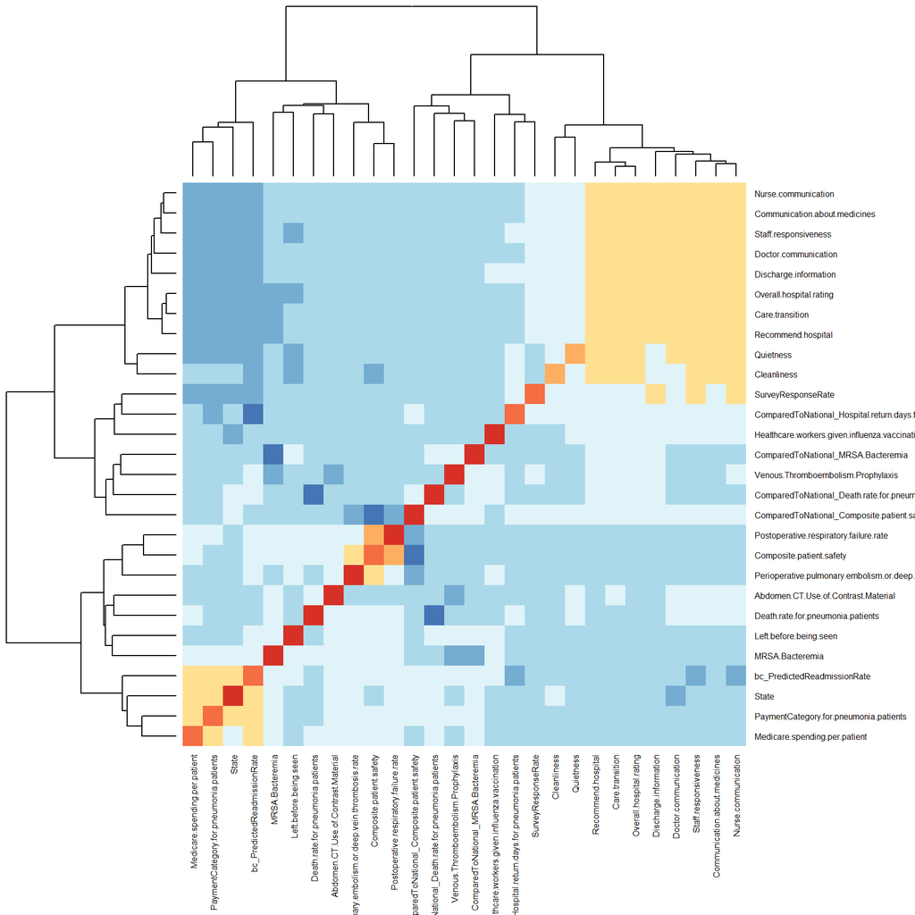

Figure 9. Correlation Heatmap of All Variables

#### **Question 20A**: [1 point]

Where do you see the highest potential for multicollinearity? Why do you say that?

> Your answer here. The variable composite patient safety has a higher correlation

Which variable(s) seem to be most correlated with our target, `bc_PredictedReadmissionRate`?

> Your answer here. There is some evidence of a correlation between `bc_PredictedReadmissionRate`, `State`, `Payment category for pneumonia patients`, `Medicare spending per patient`

## 4.2 Fitting a model to estimate VIF

Another way we can assess multicollinearity is by fitting a multiple linear regression model and estimating the **variance inflation factors**, or VIF, which estimates how much the variance of an estimated regression coefficient increases if your predictors are correlated. Specifically, variance inflation can identify **multicollinearity** when the VIF is greater than ~4 and especially when it is above 10.

## 4.2.1 Fit a linear regression with the training data, using the Box-Cox transformed `Predicted Readmission Rate` as the target.

```r
mod <- lm(bc_PredictedReadmissionRate ~ ., data = readyTrain)
```

## 4.2.1 Next, let’s calculate the VIFs using the `vif()` function that is part of the `car` package.

Note that I am not printing all of the VIFs, just the top 15 after sorting in descending order.

```r
## Calculate the VIFs and put into a dataframe to print the table
vifResults <- vif(mod) %>% data.frame
## Change the column names of the dataframe
colnames(vifResults) <- c("VIF")
```

Table 7. Top 15 Variance Inflation Factors after multiple linear regression

|  | VIF |
| --- | --- |
| Overall.hospital.rating | 22.69 |
| Recommend.hospital | 14.77 |
| Nurse.communication | 8.35 |
| Care.transition | 8.02 |
| Staff.responsiveness | 5.26 |
| Communication.about.medicines | 4.59 |
| Doctor.communication | 4.19 |
| Discharge.information | 3.48 |
| Composite.patient.safety | 2.74 |
| Quietness | 2.35 |
| ComparedToNational_Composite.patient.safety | 1.87 |
| Death.rate.for.pneumonia.patients | 1.85 |
| Cleanliness | 1.79 |
| ComparedToNational_Death.rate.for.pneumonia.patients | 1.76 |
| Postoperative.respiratory.failure.rate | 1.56 |

#### **Question 20B**: [1 point]

Does multicollinearity seem to be an issue in this dataset and, if so, among which variables? Why do you come to this conclusion?

**HINT 1**: What was used to calculate `Overall Hospital Rating`? Does this help us better understand why the VIF is so large?

**HINT 2**: Is, for example,`Payment Category for pneumonia patients` created from `Payment for pneumonia patients`? [These are Medicare payments]? Which one do you think we should keep amd why?

> Your answer here. VIF values greater than 5 can indicate a severe correlation between predictors. Overall.hospital.rating 22.69 Recommend.hospital 14.77 Nurse.communication 8.35 Care.transition 8.02 Staff.responsiveness 5.26

Which variable(s) seem to be most highly correlated with our target? Is it a positive or negative correlation? Does it make sense?

### 4.3 Dropping the most collinear variables

Even though we plan to proceed with an elastic net (which is much more robust to multicollinearity), some of these VIFs are too high for comfort. We also want to pause and ask - **were any of the variables used to make other variables?** (The answer is “yes”!). Those are excellent candidates to scrub too; we want to use our domain knowledge and what our stakeholders are asking for to help us decide which ones to keep.

Because the goal is a deployable predictive model, we likely want something more granular than most of the `ComparedToNational` features can give us, with the **exception of our key predictor**, `ComparedToNational_Hospital return days for pneumonia patients`. I will remind you of what we explored in Section 2 with this variable; not only that, we can see how **how highly correlated it is with our target!**.

### 4.3.1 Drop variables with VIF over 5 from both the training and testing data

```r
## Drop those with VIF over 5
vifOver5 <- vifResults %>% filter(VIF >=5) %>% rownames()
print(vifOver5)
```

```
## [1] "Nurse.communication"     "Staff.responsiveness"
## [3] "Care.transition"         "Overall.hospital.rating"
## [5] "Recommend.hospital"
```

```r
## Now drop them
readyTrain <- readyTrain %>% select(-any_of(vifOver5))
readyTest <- readyTest %>% select(-any_of(vifOver5))
```

```r
readyTrain <- readyTrain %>%
  ## Rename the column we want to keep
  rename(Hospital.return.days.for.pneumonia.patients = ComparedToNational_Hospital.return.days.for.pneumonia.patients) %>%
  ## Drop all the other columns
  select(-contains("Compared"), -contains("PaymentCategory"), -SurveyResponseRate)

readyTest <- readyTest %>%
  ## Rename the column we want to keep
  rename(Hospital.return.days.for.pneumonia.patients = ComparedToNational_Hospital.return.days.for.pneumonia.patients) %>%
  ## Drop all the other columns
  select(-contains("Compared"))
```

# 5 Unsupervised Learning Methods: Segmentation Analysis

Predictive modeling is our ultimate goal, but let’s pretend our stakeholders have expressed a desire to better understand how the hospitals relate to one another and whether there are any general patterns we should be interested in for enhanced interpretation. After all, a prediction is one thing, but understanding the *why* is still usually important!

Thus, we have opted to undertake a **Segmentation Analysis** to see if there is any underlying segments, or clusters, of hospitals based on the data we have. We will use the unsupervised methods of Principal Component Analysis (PCA) and $k$-means clustering do this; it will help us to determine if there are broader classifications of our hospitals that we need to report back to the advocacy group.

## 5.1 Principal Component Analysis

First, we apply a PCA on the data and display the principal components. Note that we have the same number of **principal components** as we do variables in the data set! The *cumulative proportion* of variance adds to 100% by our last principal component; but we’re really more interested in the portion of variance explained by EACH of the principal components. This can help us figure out just how many PCs are important for explaining the most variance. For example, if we were interested in feature reduction, we could use the top PCs that explain, say, some portion of the variance that we wish to retain.

#### **Question 21**: [2 points]

1. At what principal component do we surpass 80% of explained variance? (**HINT**: look at the cumulative variance row rather than tha proportion of variance row).

> Your answer here. PC11 surpasses 80% of the explained variance

```r
pca <- prcomp(readyTrain)
summary(pca)
```

```
## Importance of components:
##                           PC1    PC2     PC3     PC4     PC5     PC6     PC7
## Standard deviation     2.0083 1.3531 1.23770 1.15277 1.11902 0.98837 0.95617
## Proportion of Variance 0.2241 0.1017 0.08511 0.07383 0.06957 0.05427 0.05079
## Cumulative Proportion  0.2241 0.3258 0.41089 0.48472 0.55429 0.60856 0.65935
##                            PC8     PC9   PC10    PC11    PC12    PC13    PC14
## Standard deviation     0.93867 0.92718 0.8807 0.85563 0.81030 0.73429 0.68600
## Proportion of Variance 0.04895 0.04776 0.0431 0.04067 0.03648 0.02995 0.02614
## Cumulative Proportion  0.70830 0.75606 0.7992 0.83983 0.87631 0.90626 0.93240
##                           PC15    PC16    PC17    PC18
## Standard deviation     0.65207 0.58828 0.50527 0.43607
## Proportion of Variance 0.02362 0.01923 0.01418 0.01056
## Cumulative Proportion  0.95603 0.97525 0.98944 1.00000
```

2. You may also notice that this is always ordered from most proportion of variance on the left (thus is PC1 defined) to our final principal component on the right. What percent of variance is explained by just PC1? What percent by the final PC? Is the attributable portion of the variance in PC1 high, medium, or low based on some quick research or prior knowledge?

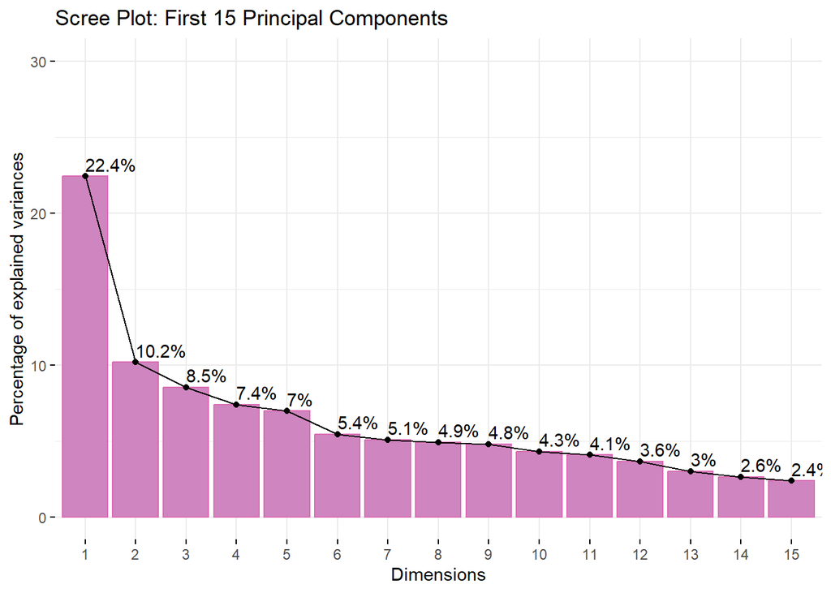

Figure 10. Scree Plot of First 15 Principal Components

How many PCs appear optimal to you based on the scree plot?

> Your answer here. There is a defined elbow at 6 principal components
4. People often mis-write scree (I’ve even accidentally done it) as SCREE, as if it’s an acronym like AUROC or ROC or even PCA. But it’s not. Why is it called a scree plot? (**Hint**: It may not be what you expect!)

> Your answer here. In the PCA literature, the plot is called a ‘Scree’ Plot because it often looks like a ‘scree’ slope, where rocks have fallen down and accumulated on the side of a mountain.) (medium.com)

### 5.1.2 Variable loadings and contributions

Next, let’s explore how much the variables are contributing (this is based on the weight of their rotations). In PCA, we are interested in the **loadings**, i.e., the linear combination weights (coefficients) whereby unit-scaled components define or “load” a variable. Loadings help us interpret principal components.

You may have noticed we used the `prcomp()` function above; `prcomp()` will return the loadings in the variable `$rotation`, which contains a matrix of variable loadings. These loadings have been determined from the eigenvectors, which without getting into what that is (because we’d have to take a departure into linear algebra), suffice it to say that they are how we are measuring the direction and magnitude during each subsequent rotation of the principal components as we measure the variance explained.

Additionally, we are going to color this by our grouping variable and key predictor in the dataset, `Hospital.return.days.for.pneumonia.patients`. Recall that when we explored this earlier this variable is the performance of each hospital in terms of its pneumonia-related return-to-hospital days relative to the national average. In other words, hospitals that were “Worse than average” had readmitted pneumonia patients with longer-than-average stays.

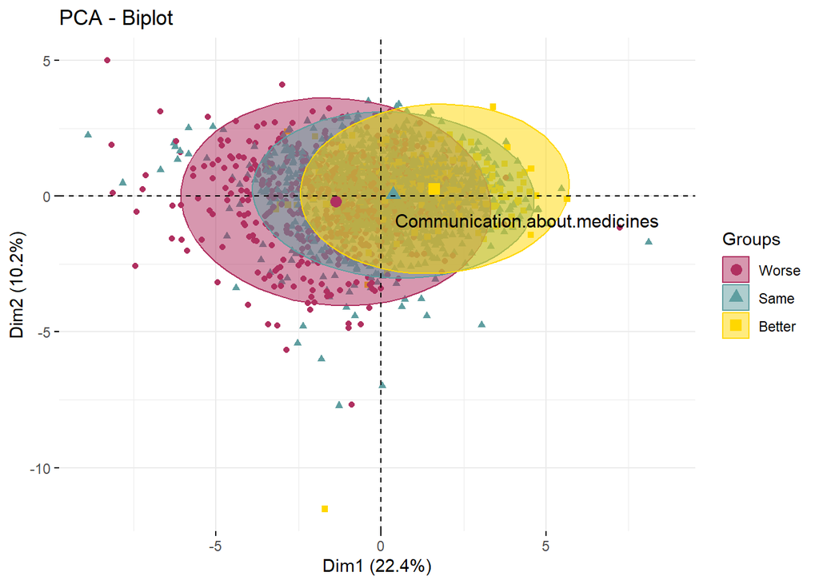

Figure 11. PCA Biplot Showing the Top Feature that Contributes to Explained Variance

This biplot (Figure above) shows that, on principal components 1 and 2 (the PCs that account for the **most** variance in the training data) there is subtle but noticeable grouping of hospitals in terms of how long their readmitted pneumonia patients stayed in the hospital. I have chosen to display the **#1** feature that contributes to that variance, `Communication.about.medicines`.

**A general rule of thumb is:**

1. Top-right Quadrant I
- PC1 and PC2 are both positive
- Thus points in this quadrant are positively associated with variables pointing into this quadrant
- Indicates high values for variables with arrows in this quadrant
2. Top-left Quadrant II
- PC1 is negative, PC2 is positive
- Thus points here are associated with high values of variables pointing to the left and top
- These observations contrast with those in the right-side quadrants on PC1
3. Bottom-left Quadrant III
- PC1 and PC2 are both negative
- Thus points here are negatively associated with variables pointing into the other quadrants
- These points could represent a distinct subgroup or pattern with behavior opposite to other points.
4. Bottom-right Quadrant IV
- PC1 is positive, PC2 is negative
- Thus points here are associated with variables pointing *into* this quadrant
- May indicate a contrast with Quadrant II on PC2

#### **Question 22**: [1 point]

Play around with the graphical parameters in the biplot, especially those I’ve marked with comments. Try adding, for example, more variables to display rather than just the top contributor. **NOTE** that if you find variables in the same quadrant together, this means that they are correlated. What variable(s) can you find that **contrast** with `Communication.about.medicines`?

> Your answer here.

Now, look at the contributions to PCs 1 and 2 (Figure Below) from the variables in the training dataset. Anything above the dotted red-line contributes **significantly** to the overall explanation of variance, and anything below the dotted line does not. Does anything about this plot stand out to you?

**HINT 1**: What do the top contributing variables all have in common? In other words, did they all come from the same data source?

**HINT 2**: Where does the target, `PredictedReasmissionRate`, fall among the significant variables?

> Your answer here. The target variable `PredictedReasmissionRate` is at the dotted red line (which represents the variance of the target) many of the top contributing variables all sound like patient complaints about hospital service.

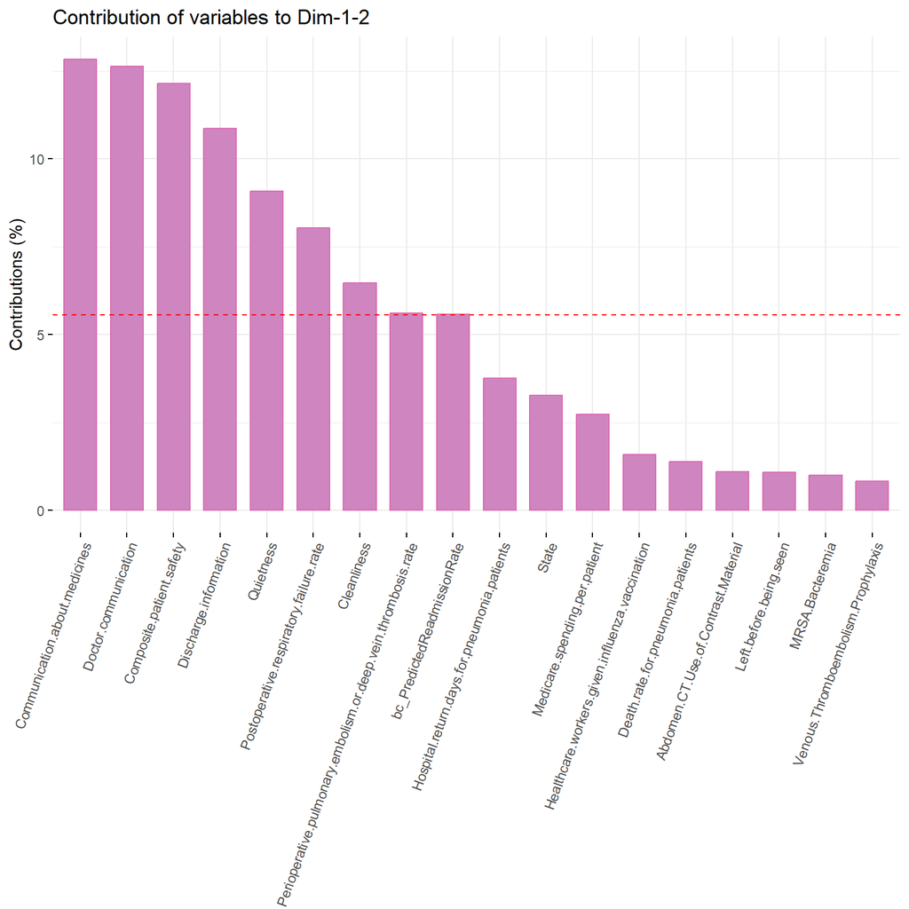

Figure 12. Variables that Significantly Explain Variance.

## 5.2 *k*-means Clustering

$k$-means is a centroid-based clustering algorithm, where a “centroid” is the geometric center of an object often measured by Euclidean distance. In the algorithm, the distance between each data point and a centroid is calculated by randomly grabbing data; these distances are then used to assign the data point to a cluster. The goal is to identify the optimal $k$ number of groups in a dataset by minimizing the distance of each datapoint to a respective centroid.

### 5.2.1 Visualizing Clusters

Although multiple methods exist to determine the optimal number of clusters, one commonly employed is **heuristic**, i.e., it isn’t really computational. You will either choose the optimal clusters based on a set of options of $k$ graphically or you can once again employ the “elbow” method again, as you did with PCA. Let’s start by visually inspecting the effect of different $k$ clusters on PC1 and PC2 of the dataset. I have chosen to test $k$ groups of 2 through 9.

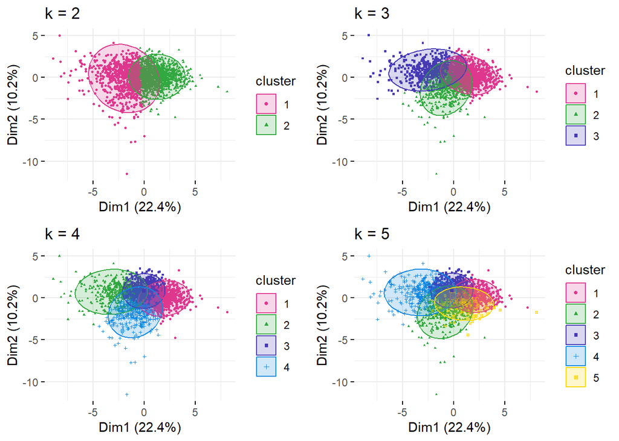

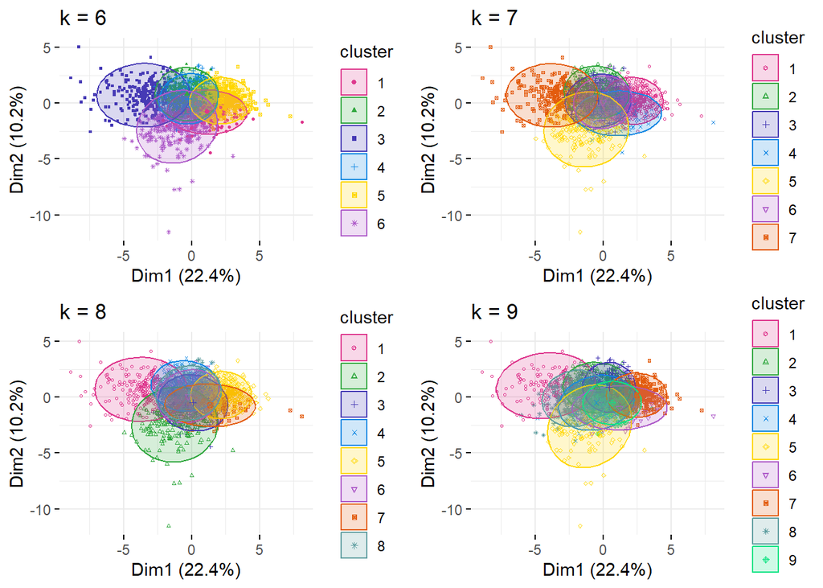

##### Figure 13. Biplots showing possible k clusters

#### **Question 23A**: [0.5 points]

Which number of clusters, $k$, do you think has the best explanatory power? Why? Is it is hard to tell?

> Your answer here I would prefer K=6, beyond that there is a lot of overlap in the clusters.

### 5.2.3 Within-sum-of-squares (WSS) elbow method

Next, let’s employ the ‘elbow’ method again, this time to look at when the **within sum of squares** drops off rather than the percent variance, as was done in PCA.

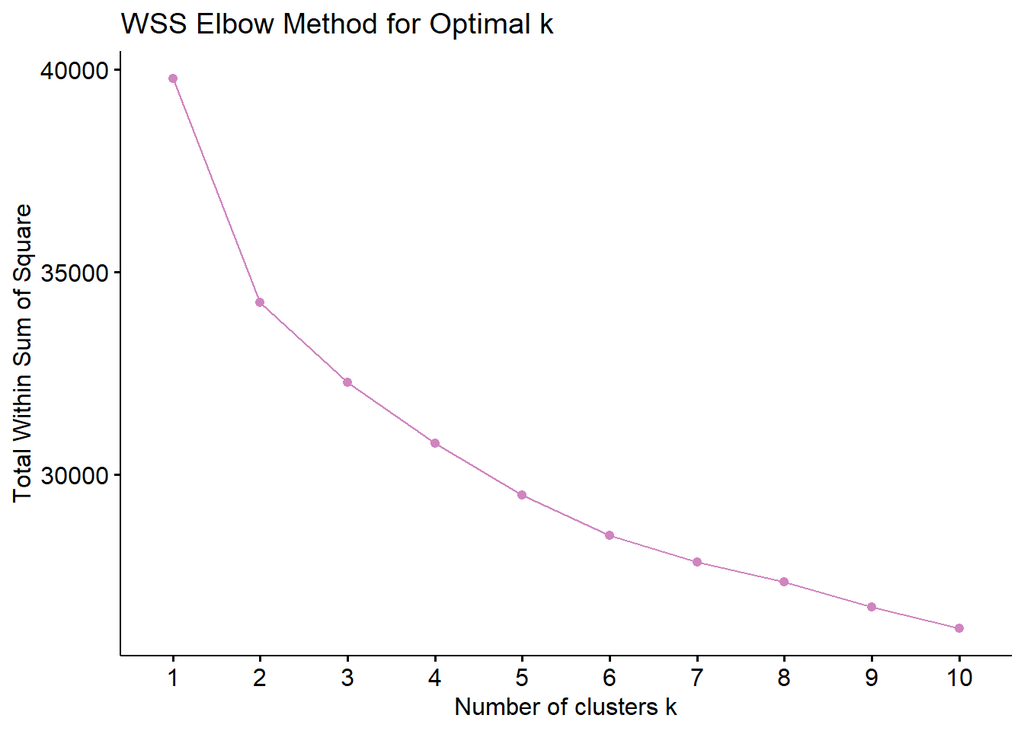

Figure 14. WSS Scree plot for k-means

#### **Question 23B**: [1 point]

What is the **within sum of squares** and what exactly is it measuring here? By the elbow method, which $k$ is the optimal number of clusters? Did it agree with your choice from the other heuristic method?

> Your answer here in this Scree plot it is difficult to tell. Maybe 6, but not a defined elbow (maybe at 2, which is well-defined elbow, but that seems too low).

### 5.2.3 Silhouette method

Lastly, we will apply the **silhouette method**, which measures the average silhouette width, a combination of (1) how similar any given point is to its own cluster (also called **cohesion**) and (2) how different that same point is from other clusters (also called **separation**). Silhouette scores can range from $-1 \rightarrow +1$, with larger values indicating better clustering (i.e., more cohesive clusters that are separated from each other). Thus, a silhouette score of 1 indicates **perfect separation and cohesion** whereas a silhouette of 0 indicates overlapping clusters.

What we can do is iteratively test our possible $k$ values of 2 to 9 and a silhouette score will be calculated for each $k$ tested. The highest silhouette score indicates the optimal $k$.

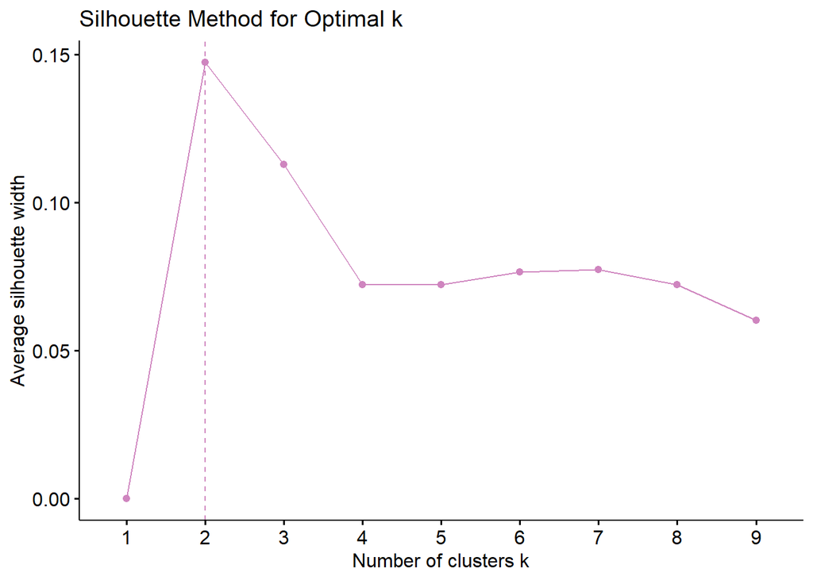

Figure 14. Silhouette Plot for k-means

#### **Question 23C**: [0.5 points]

Are you surprised at the optimal $k$ from the silhouette method? Does it seem to agree with what you’ve seen with the WSS elbow method? (**Hint**: agreement generally suggests evidence that you have found the optimal $k$).

> Your answer here Surprised at the silhouette method identifying 2 clusters as optimal, but that corresponds with the WSS only visible elbow at 2 (even though 2 seemed low).

Lastly, let’s extract the optimal $k$ from the silhouette method.

```r
## Extract optimal k from silhouette method; first get the cluster data
clusterData <- fviz_nbclust(readyTrain, kmeans, method = "silhouette")$data
## Then extract the maximum y
k <- as.numeric(clusterData$clusters[which.max(clusterData$y)])
```

## 5.3 Segmentation Analysis

As we said before, the goal of segmentation analysis is to broadly cluster our hospitals by their features to help us characterize them.

#### **Question 24**: [1 point]

Let’s explore the clusters - segments - of the hospitals based on their average values from the **original** dataset (we start from `imputedTrain`, which hadn’t yet been transformed, centered, or scaled, BUT the multicollinear variables also haven’t been dropped either). Your task is to add comments to this code chunk.

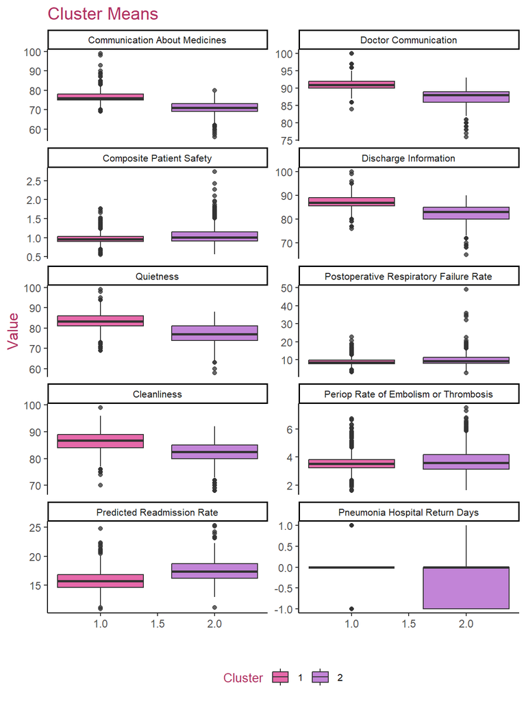

Figure 16. Boxplot Comparisons of Important Variables by Cluster

```r
## run kmeans in the training data
kmeansResult <- kmeans(readyTrain,
                         centers = k,      ## indicate to kmeans to find the most appropriate cluster number and optimal centers
                         nstart = 50,
                         iter.max = 1000,
                         algorithm = "MacQueen")
## kmeansTrain is from the imputedTrain dataset
kmeansTrain <- imputedTrain %>%
  ## Rename the column we want to keep
  rename(Pneumonia.Hospital.Return.Days = `ComparedToNational_Hospital return days for pneumonia patients`) %>%
  ## Select only the columns with a VIF > 5, but drop columns that contain names of Compared, PaymentCategory, or SurveyResponseRate
  select(-any_of(vifOver5), -contains("Compared"), -contains("PaymentCategory"), -SurveyResponseRate) %>%
  ## mutate a column called cluster that is either 0 or 1
  mutate(Cluster = kmeansResult$cluster,
         Pneumonia.Hospital.Return.Days = as.numeric(if_else(Pneumonia.Hospital.Return.Days == "1", 1,
                                                     if_else(Pneumonia.Hospital.Return.Days == "0", 0, -1)))) %>%
  ## clean_names function, to cleanup the names of the dataframe (lowercase and puts underscore in spaces)
  clean_names()

## Using % contribution graph, the order of the top 10:
pcaImportantVars <- factor(c("Communication.about.medicines",
                       "Doctor.communication",
                       "Composite.patient.safety",
                       "Discharge.information",
                       "Quietness",
                       "Postoperative.respiratory.failure.rate",
                       "Cleanliness",
                       "Periop.Rate.Of.Embolism.Or.Thrombosis",
                       "Predicted.Readmission.Rate",
                       "Pneumonia.Hospital.Return.Days"))

## convert pcaImportantVars to lowercase
pcaImportantVars <- tolower(pcaImportantVars)
## remove periods and underscores
pcaImportantVars <- gsub("\\.", "_", pcaImportantVars) %>%
## turn to uppercase
  to_any_case("title")

## COMMENT HERE
kmeansTrain %>%
  ## COMMENT HERE
  rename(Predicted.Readmission.Rate = predicted_readmission_rate,
         Periop.Rate.Of.Embolism.Or.Thrombosis = perioperative_pulmonary_embolism_or_deep_vein_thrombosis_rate) %>%
  ## COMMENT HERE
  clean_names(case = "title") %>%
  ## COMMENT HERE
  select(Cluster, any_of(pcaImportantVars)) %>%
  ## COMMENT HERE
  pivot_longer(-1, names_to = "Measure", values_to = "Value") %>%
  ## COMMENT HERE
  # filter(Measure %in% pcaImportantVars) %>%
   mutate(Measure = factor(Measure, levels = to_any_case(c("Communication.about.medicines",
                        "Doctor.communication",
                        "Composite.patient.safety",
                        "Discharge.information",
                        "Quietness",
                        "Postoperative.respiratory.failure.rate",
                        "Cleanliness",
                        "Periop.Rate.Of.Embolism.Or.Thrombosis",
                        "Predicted.Readmission.Rate",
                        "Pneumonia.Hospital.Return.Days"), case="title"))) %>%
  ## ggplot of clusters
    ggplot(aes(x = Cluster, y = Value, fill = as.factor(Cluster))) +
    geom_boxplot(alpha=0.75) +
    scale_fill_manual(values = c(skittles[1], skittles[6])) +
    labs(title = "Cluster Means",
         x = "",
         fill = "Cluster") +
    theme_classic() +
    theme(legend.position = "bottom",
        strip.text = element_text(size=8),
        legend.text = element_text(size = 8),
        legend.title = element_text(size = 10),
        title = element_text(size = 12, color = "maroon")) +
    ## using facets in ggplot, 2 columns
    facet_wrap(~ Measure,
             scales = "free_y",
             ncol = 2)
```

```r
## COMMENT HERE
kmeansTrain %>%
  ## column renames
  rename(Predicted.Readmission.Rate = predicted_readmission_rate,
         Periop.Rate.Of.Embolism.Or.Thrombosis = perioperative_pulmonary_embolism_or_deep_vein_thrombosis_rate) %>%
  ## COMMENT H
  clean_names(case = "title") %>%
  ## COMMENT HERE
  select(Cluster, any_of(pcaImportantVars)) %>%
  ## produce a cluster summary table
  tbl_summary(by = "Cluster",
              statistic = list(all_continuous() ~ c("{mean} ({median})"))) %>%
  modify_header(label ~ "Variable",
                all_stat_cols() ~ "**Cluster {level}**") %>%
  modify_caption("Table 8. Summary Statistics of Important Cluster Variables")
```

Table 8. Summary Statistics of Important Cluster Variables

| Variable | **Cluster 1**<sup>1</sup> | **Cluster 2**<sup>1</sup> |
| --- | --- | --- |
| Communication About Medicines | 76.5 (76.0) | 70.9 (71.0) |
| Doctor Communication | 91.03 (91.00) | 87.68 (88.00) |
| Composite Patient Safety | 0.98 (0.96) | 1.06 (1.01) |
| Discharge Information | 87.0 (87.0) | 82.3 (83.0) |
| Quietness | 83.2 (83.4) | 77.1 (77.0) |
| Postoperative Respiratory Failure Rate | 8.69 (8.53) | 9.93 (9.25) |
| Cleanliness | 86.4 (86.8) | 82.1 (82.6) |
| Periop Rate of Embolism or Thrombosis | 3.55 (3.52) | 3.73 (3.59) |
| Predicted Readmission Rate | 15.77 (15.67) | 17.57 (17.38) |
| Pneumonia Hospital Return Days |  |  |
| -1 | 188 (14%) | 430 (50%) |
| 0 | 976 (72%) | 408 (47%) |
| 1 | 185 (14%) | 23 (2.7%) |

<sup>1</sup> Mean (Median); n (%)

**HINT**: If these are back to the *original* values, this is more interpretable for our stakeholder. We will now read this just like a typical boxplot; for example, median (the middle line) `Doctor Communication` seems higher in **Cluster 1** than it does in **Cluster 2** with only some overlap in the distributions (the boxes and whiskers don’t really overlap each other). The table confirms this; the median `Doctor Communication` score is 91% in Cluster 1 but only 88% in Cluster 2.

#### **Question 25**: [2 points]

Notice, for example, that Cluster 1 hospitals seem to include the hospitals that had the **lowest** pneumonia-related readmission rates, with the average rate ~2% higher in Cluster 2 hospitals. Thus, for our stakeholder, we might decide to rename Cluster 1 as “Highest Performing Hospitals” or something along those lines. Notice also that this cluster had more **below** national average return hospital days (a “1”). This means that they had more readmitted pneumonia patients who spent less time in the hospital upon readmission than the national average.

Look at how else you might broadly characterize - or segment - these hospitals. Your job is to make a table for your client, summarizing each of the two clusters with FOUR primary criteria. Make sure to give each cluster an informative name as I did; you’re welcome to rename Cluster 1 if you think of a catchier name than I chose!

After you come up with names of the two clusters, you will then come up with at least FOUR characteristics per cluster summarizing what you see in either the boxplots or table. You may choose to focus on different attributes for different clusters. Fill in the code for the table below. I start you out with two examples for Cluster 1, but feel free to add more!

| Top Defining Attributes | Description |
| --- | --- |
| **1: Highest Performing Hospitals** |  |
| Predicted Pneumonia-related hospital readmissions | These hospitals have a lower readmission rate, suggesting that hospitals in this cluster may be better at diagnosing and treating pneumonia |
| Return hospital days due to pneumonia | Readmitted patients spend below the national average number of days in hospital, suggesting these hospitals are able to more quickly treat and stabilize pnuemonia patients |
| Doctor Communication | These hospitals had a higher rate of doctor communication verus lower-performing hospitals. |
| Cleanliness | Higher performing hospitals have a higher rate of overall cleanliness. |
| **2: Lower-Performing Hospitals** |  |
| Discharge Information | Lower-performing hospitals have a lower rate of discharge information, which may increase readmission risk for patients. |
| Communication about Medicines | Lower-performing hospitals had a lower rate of communication about medicines, which may contribute to misunderstanding, and medication non-compliance. |
| Quietness | Overall, hospital quietness was rated lower for this cluster, which may have a negative affect on patient recovery times. |
| Post-Operative Respiratory Failure Rate | Lower-rated hospitals have a slightly higher median rate, but also a much higher range of post-operative respiratory failure |

## 5.4 Final Remarks on Segmentation

We don’t technically have to stop our segmentation analysis here, but we will so that we can focus on other analyses. One thing we might choose to do in the future, for example, is to choose a classification machine learning algorithm to test the predictions based on these clusters.

#### **Question 26**: [1 point]

Make a recommendation for our client for 1-2 machine learning analyses **your team** would choose to use to test whether these clusters can be used for robust predictions of hospital performance for pneumonia patients. How would you know whether or not your predictions were robust? What would you look for or compare?

> Your answer here. The cluster labels themselves can be used in a supervised learning model to predict new clusters.

# 6 Supervised Learning Methods

We are going to perform two supervised learning methods: an Ordinary Least Squares (OLS) regression followed by an Elastic Net.

## 6.1 Ordinary Least Squares (OLS) regression

Earlier in Section 4 when we assessed multicollinearity, we fit an OLS regression model so that we could calculate variance inflation factors (VIFs). However, because OLS regression is so incredibly sensitive to multicollinearity, we should re-run it now that we’ve removed some of the most redundant variables.

Let’s model that now, using the `readyTrain` dataset and plot some diagnostic plots. to assess the key assumptions of an OLS linear regression. The four plots are diagnostic plots for the primary assumptions of a linear regression:

1. **Linearity** between the outcome and the predictors
2. **Normally distributed** residuals
3. **Homosecadasticity** (equality of variances) in the residuals
4. **No high leverage/influence points** (no significant outliers)

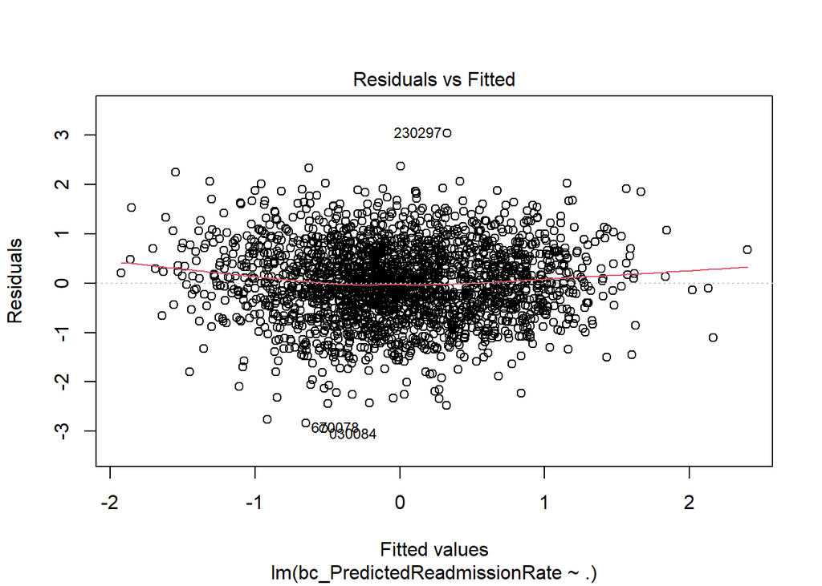

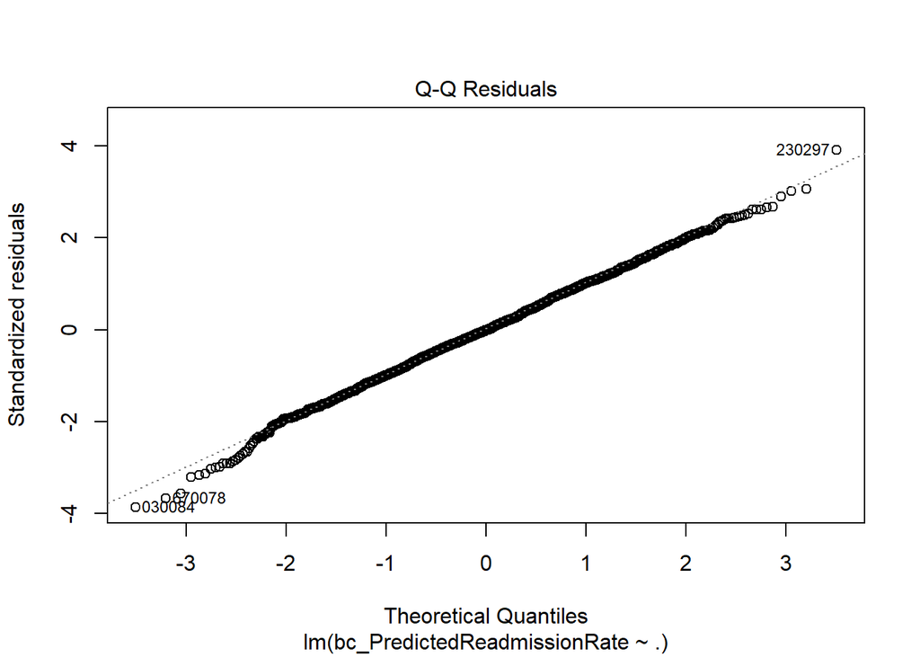

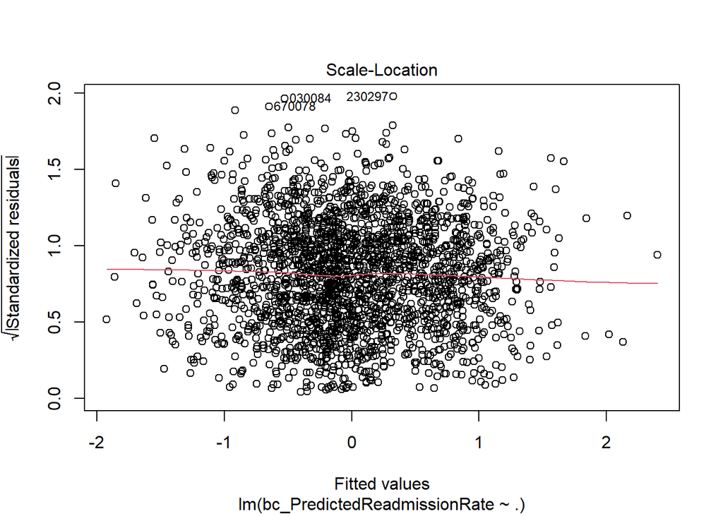

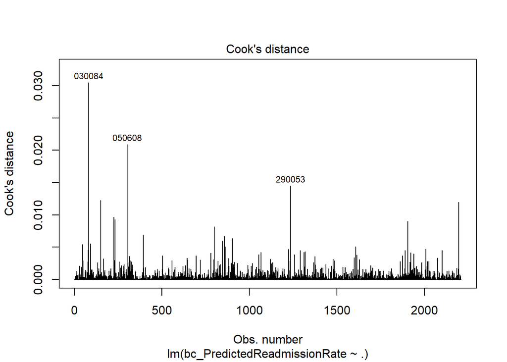

##### Figure 17. OLS Regression Assumption Diagnostic Plots

#### **Question 27A**: [1 point]

What is your general assessment of our OLS assumptions? Met or unmet? Why?

> Your answer here. The Q-Q plot looks normal and the residals suggest homoscedasticity

**Note:** If you are not entirely sure about the Q-Q plot, you can run a Shapiro-Wilk test on the residuals using the following code:

```r
shapiro.test(residuals(mod))
```

```
##
##  Shapiro-Wilk normality test
##
## data:  residuals(mod)
## W = 0.99862, p-value = 0.06735
```

The **most important** OLS assumption for Elastic Net is **linearity of the relationship between predictors and the response**. The other, stricter OLS assumptions don’t matter as much because of regularization.

**Do you find support for linearity here**? Why or why not?

> Your answer here. # yes, because the shapiro-wilk test has a p value > .05
2. Let’s now assess how well our model fits with the adjusted $R^2$.

```
## [1] 0.39427
```

#### **Question 27B**: [1 point]

> Your answer here. Adjusted R squared is more reliable to measure model accuracy when there are multiple predictors.
3. Find the best model.

Use the `step()` function to do a backward regression to find our **most parsimonious** model. Stepwise regression drops terms that are not significant or important, thereby only keeping the features that contribute to the overall explanation of variance in predicted readmission rate.

```r
## Perform a backward, stepwise regression to find the most parsimonious model
bestMod <- step(mod,
            direction = "backward",
            trace = FALSE)
```

Lastly, let’s take a peek at the results. We will use a package called `stargazer` to help us visualize the results in a nicely organized way.

```r
## Print a table using stargazer
stargazer(bestMod,
          type = "html",
          title = "Table 10. Parsimonious OLS Regression Results.")
```

**Table 10. Parsimonious OLS Regression Results.**

|  | *Dependent variable:* |
| --- | --- |
|  | bc_PredictedReadmissionRate |
| MRSA.Bacteremia | 0.039** |
|  | (0.017) |
| Abdomen.CT.Use.of.Contrast.Material | 0.045*** |
|  | (0.017) |
| Death.rate.for.pneumonia.patients | -0.154*** |
|  | (0.017) |
| Medicare.spending.per.patient | 0.167*** |
|  | (0.018) |
| Healthcare.workers.given.influenza.vaccination | 0.044** |
|  | (0.018) |
| Left.before.being.seen | 0.062*** |
|  | (0.017) |
| Venous.Thromboembolism.Prophylaxis | 0.101*** |
|  | (0.018) |
| Doctor.communication | -0.074*** |
|  | (0.027) |
| Discharge.information | -0.053** |
|  | (0.024) |
| Cleanliness | -0.053*** |
|  | (0.020) |
| Quietness | -0.077*** |
|  | (0.022) |
| Hospital.return.days.for.pneumonia.patients | -0.396*** |
|  | (0.018) |
| State | 0.110*** |
|  | (0.019) |
| Constant | 0.000 |
|  | (0.017) |
| Observations | 2,210 |
| R<sup>2</sup> | 0.398 |
| Adjusted R<sup>2</sup> | 0.395 |
| Residual Std. Error | 0.778 (df = 2196) |
| F Statistic | 111.824*** (df = 13; 2196) |
| *Note:* | p<0.1; p<0.05; p<0.01 |

Lastly, let’s assess how good a predictive model our OLS regression model is. We will use the `predict()` function to first fit our most parsimonious model `bestMod` to the test data:

```r
## Make the predictions
predictions <- predict(bestMod, newdata = readyTest)
```

The Root Square Mean Error ($RMSE$) is the square root of the average of the squared differences between predicted and actual value, such that $RMSE = \sqrt{\frac{1}{n}\sum_{i=1}^n\cdot(y_i-\hat{y}_i)^2}$ where $y_i$ is each observed value, $\hat{y}_i$ is each corresponding predicted value, and $n$ is the number of observations. **NOTE**: Recall that a residual is $y_i-\hat{y}_i$ - the distance between every point and its predicted value! It’s also important to realize that the $RMSE$ gives more weight to large errors because of squaring. Thus, it’s sensitive to outliers.

#### **Question 27C**: [1 point]

Can you interpret what the RMSE tells your client here? Why or why not? What about the $R^2$?

**Hint 1**: Remember that the outcome here is Box-Cox transformed. Would you need to undo the transformation to be able to assess what the RMSE (or $R^2$) is actually telling us? Recall that the Box-Cox $\hat{y} = \frac{1}{y^\lambda}$ where our $\lambda = -0.3$ AND we also centered and scaled these data.

**Hint 2**: Is it practical to undo both transformations? How does that hinder our ability to make an interpretation for our client?

Lastly, let’s graph the effect predictive ability of our OLS model by comparing the relationship between the **true** values of `bc_PredictedReadmissionRate` from the `readyTest` dataset to the predictions we made using the model on the testing data.

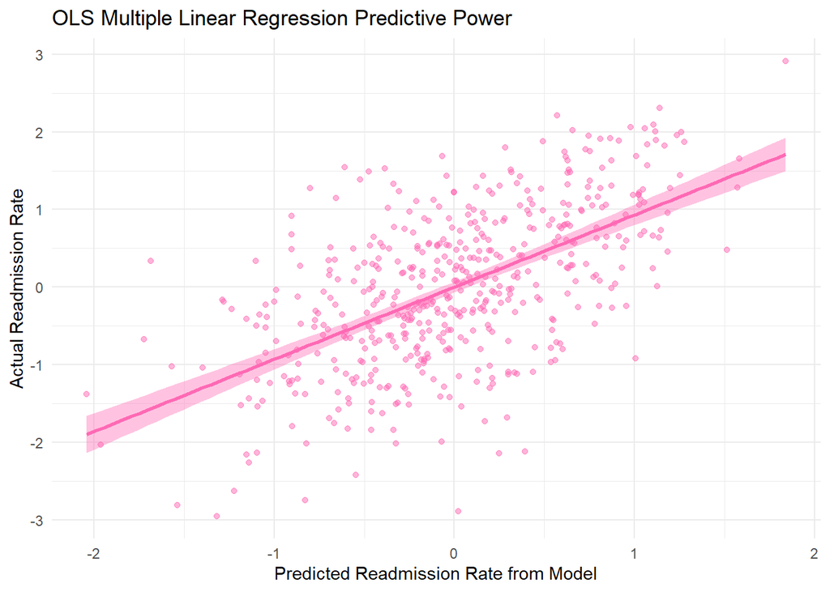

Figure 18. Predictions Plot for OLS Regression

**NOTE** that, while there is an obvious linear trend, it is weak. There is a lot of error around the predictions from the OLS regression!

## 6.2 The Elastic Net

Perhaps the seemingly low $R^2$ is because we still have too much multicollinearity or overfitting. So, as we discussed in lecture, we can address this using regularized regressions, such as the **Elastic Net**, which is more robust to multicollinearity by assessing penalties for non-zero variance. Typically, we would likely conduct a Ridge and/or LASSO before running an Elastic Net, but since we already know that (1) we have a fairly high amount of multicollinearity in our original `readyTrain` dataset and (2) we know we want to be able to perform feature reduction and figure out which features are important predictors of hospital readmissions, we’re going to jump straight into Elastic Net, which performs both.

### 6.2.1 The Elastic Net Unpacked

In general, regularization is a technique that applies a penalty term to a cost function of a machine learning model, like the OLS regression. The reason is to discourage overfitting. This penalty term constrains the model’s coefficients, which limits how flexible they are during training. Why?

The more flexible the coefficients, the less likely they will “learn” new data, i.e., the more generalizable they are! Thus, by applying this penalty (constraint), it improves the model’s performance on “unseen” or new data.

As mentioned in lecture, Elastic Net regression is a general regularization technique that combines the regularization techniques of Ridge and LASSO to help us perform both feature selection (i.e., significant coefficients) and feature reduction (importance). The elastic net can even help us with the $P >> n$ problem! Elastic net has two regularization terms, called **L1** (or the Lasso regularization term) and **L2** (the Ridge term).

- **L1**: makes some of the coefficients zero, thereby selecting only the most important features (shrinks them to zero). It is often said that this **encourages sparsity in the model**.
- **L2**: reduces the coefficients to small but non-zero values, thereby reducing the coefficients of the unimportant features (which we can use to determine significance). It does this by adding a penalty term to the cost function of the model, which is proportional to the coefficient squared. This allows us to retain all the features in the model but reduces the overall impact of the non-significant or less-important ones.

Thus, by combining these techniques together, the Elastic Net is balancing feature selection with feature reduction! If you’re interested in reading the original paper on Elastic Net by Zou and Hastie (2005), you can find a free PDF of the paper [here](https://www.stat.purdue.edu/~tlzhang/mathstat/ElasticNet.pdf).

### 6.2.2 Running, tuning, & cross-validating the Elastic Net

The elastic net can be run using the `glmnet` package (which we are accessing via `caret`), and can be cross-validated as random forest and SVM from our last project could be. This is a big improvement over OLS regression, which cannot be tuned. Additionally, the elastic net has **two hyperparameters** that we can tune, $\alpha$ and $\lambda$ (not to be confused with the $\lambda$ from Box-Cox transformation - Greek letters are abundant in statistics! Why do you think I named our course teams as I did?!).

#### 6.2.2.1 We will start by setting our CV parameters just as we did on the last project, using the `trainControl()` function in `caret`.

**NOTE** that I am performing a 5-fold repeated cross-validation (CV) with 5 iterations.

```r
ctrl <- trainControl(method = "repeatedcv",  ## Do repeated CV
                     number = 5,             ## Number of k-folds
                     repeats = 5,            ## Number of repeats
                     search = "grid",        ## Grid search (vs. random)
                     verboseIter = FALSE)    ## Don't show me all the results
```

#### 6.2.2.2 Then, we fit the model using the `train()` function in `caret`, specifying that we want to perform an elastic net, which will tune the model and perform CV per the specifications in the `trainControl()`. **NOTE** that I am allowing the values of $\alpha$ to range from $0 \rightarrow 1$ and allowing $\lambda$ to range from $0 \rightarrow 5$.

```r
## Create a search grid that allows alpha to range from 0 --> and
## allows lambda to range from 0 --> 5
searchGrid <- expand.grid(.alpha = seq(0, 1, length.out = 10),
                          .lambda = seq(0, 5, length.out = 15))

## Fit the elastic net using the tuning grid and CV scheme laid out
elasticMod <- train(bc_PredictedReadmissionRate ~ .,
                    data = readyTrain,
                    method = "glmnet",
                    tuneGrid = searchGrid,
                    trControl = ctrl)
```

#### **Question 28**: [1 point]

Explain what we are doing here. You may want to look up the parameters of the `trainControl()` and `train()` functions. Make sure to address what type of CV and hyperparameter search is being performed, as well as if both the $\alpha$ and $\lambda$ hyperparameters of elastic net are being tuned.

**Hint 1**: Why are we doing cross-validation, and specifically why did I choose the one I did?

**Hint 2**: What does $\lambda = 0$ mean? How about $\alpha = 0$?

### 6.2.3 Elastic Net Results

#### 6.2.3.1 We are going to first take a look at the top 15 results of the Elastic Net in a table form, sorted from lowest $RMSE$:

Table 11. Top Performing Results of the Elastic Net Tuning & 5-fold Repeated Cross-Validation

| alpha | lambda | RMSE | Rsquared | MAE | RMSESD | RsquaredSD | MAESD |
| --- | --- | --- | --- | --- | --- | --- | --- |
| 0.00 | 0.00 | 0.78 | 0.39 | 0.62 | 0.02 | 0.03 | 0.02 |
| 0.33 | 0.00 | 0.78 | 0.39 | 0.62 | 0.02 | 0.03 | 0.02 |
| 0.56 | 0.00 | 0.78 | 0.39 | 0.62 | 0.02 | 0.03 | 0.02 |
| 0.44 | 0.00 | 0.78 | 0.39 | 0.62 | 0.02 | 0.03 | 0.02 |
| 0.22 | 0.00 | 0.78 | 0.39 | 0.62 | 0.02 | 0.03 | 0.02 |
| 0.67 | 0.00 | 0.78 | 0.39 | 0.62 | 0.02 | 0.03 | 0.02 |
| 0.78 | 0.00 | 0.78 | 0.39 | 0.62 | 0.02 | 0.03 | 0.02 |
| 0.11 | 0.00 | 0.78 | 0.39 | 0.62 | 0.02 | 0.03 | 0.02 |
| 1.00 | 0.00 | 0.78 | 0.39 | 0.62 | 0.02 | 0.03 | 0.02 |
| 0.89 | 0.00 | 0.78 | 0.39 | 0.62 | 0.02 | 0.03 | 0.02 |
| 0.00 | 0.36 | 0.79 | 0.39 | 0.63 | 0.02 | 0.03 | 0.02 |
| 0.11 | 0.36 | 0.80 | 0.38 | 0.63 | 0.02 | 0.03 | 0.02 |
| 0.00 | 0.71 | 0.80 | 0.38 | 0.64 | 0.02 | 0.03 | 0.02 |
| 0.00 | 1.07 | 0.82 | 0.37 | 0.65 | 0.02 | 0.03 | 0.02 |
| 0.00 | 1.43 | 0.83 | 0.36 | 0.66 | 0.02 | 0.04 | 0.02 |

**NOTE**: Folds that fail to converge will have an $R^2$ = `NA`.

#### 6.2.3.2 We can also extract the hyperparameters of our best tuned model:

$\alpha$:

```
## [1] 0
```

$\lambda$:

```
## [1] 0
```

#### **Question 29**: [1 point]

Check the values of $\alpha$ and $\lambda$ here. What do they suggest about the optimal regularization that is being fit here? (Recall that when both $\alpha$ and $\lambda$ are zero, it’s an OLS regression!)

Let’s also plot the results of the tuning search. Can you figure out the type of tuning search you did? (**Hint**: the visual pattern should confirm your answer from earlier!) The diamond denotes the best combination of hyperparameters!

```r
results <- elasticMod$results %>%
  data.frame()
best <- results[as.numeric(rownames(elasticMod$bestTune)), ]
```

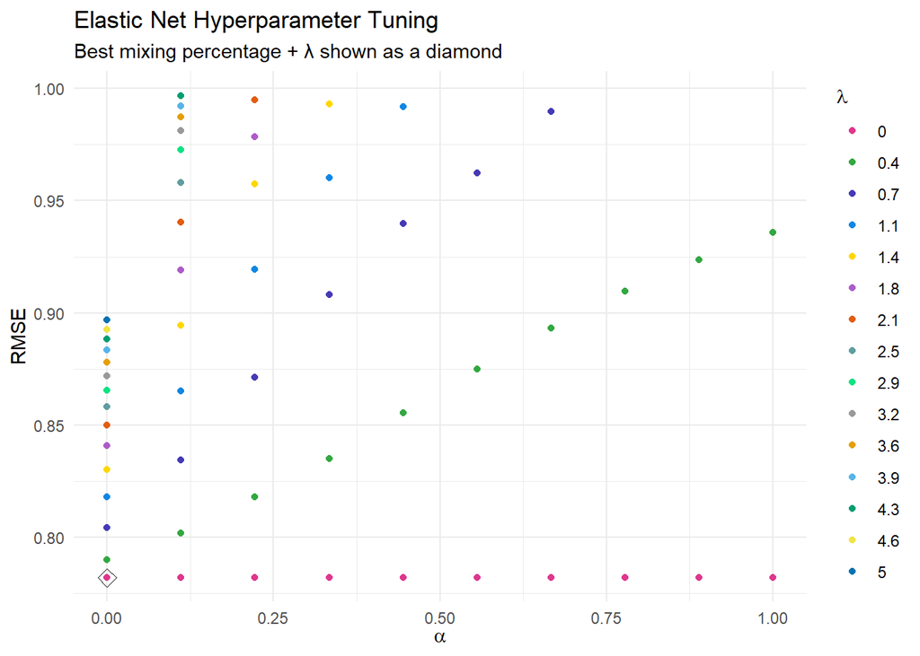

Figure 19. Hyperparamater Grid Search for Elastic Net

#### 6.2.3.3 Important Features

Important features can also be extracted, using the `varImp()` function from `caret`.

```r
important <- varImp(elasticMod)$importance
```

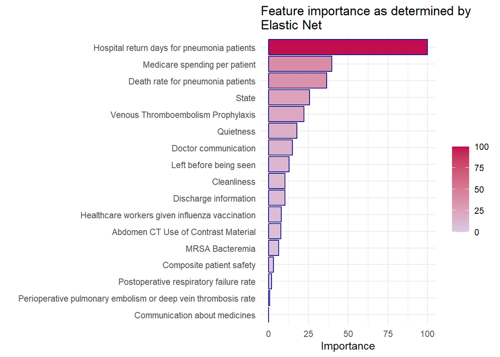

Figure 20. Variable Importance from Best Elastic Net Model

#### **Question 30**: [1 point]

Which of the features were most important? How does this compare to the most important features out of OLS regression? Make sure you’re looking at the **absolute value of the beta coefficients to assess importance in OLS regression**.

How about about of PCA? You may have already noticed that importance almost seems inverted! Why?!

**Hint 1**: What is the fundamental difference between a PCA and any regression?

**Hint 2**: What does “importance” mean in a PCA vs. any regression?

**Hint 3**: What does the sign of the loadings mean in a PCA? Are they actual or arbitrary?

> Your answer here. For PCA the signs do not matter since the variance would be the same, irrespective of sign

#### 6.2.3.2 Check model performance

Mean Absolute Error ($MAE$) is the average of the absolute differences between predicted and actual values, such that $MAE = \frac{1}{n}\sum_{i=1}^n\cdot|y_i-\hat{y}_i|$ where $y_i$ is each observed value, $\hat{y}_i$ is each corresponding predicted value, and $n$ is the number of observations. So, unlike $RMSE$, $MAE$ treats all errors equally and therefore is more robust to outliers. So, $MAE$ will tell you the average magnitude of the error, regardless of direction!

Let’s also make predictions on the testing sets for both the OLS and Elastic Net models using the `postResample()` function in `caret`; this will not only do predictions, but it will enable us to more easily generate metrics that we can use to compare model performance, such as $R^2$ and MAE.

```r
## Post-resample on OLS
prOLS <- postResample(pred = predict(mod, newdata = readyTest),
                      obs = readyTest$bc_PredictedReadmissionRate)

## Post-resample on Elastic Net
prElastic <- postResample(pred = predict(elasticMod, newdata = readyTest),
                      obs = readyTest$bc_PredictedReadmissionRate)
```

Table 12. Comparison of Model Performance of OLS and Elastic Net Regressions

|  | RMSE | Rsquared | MAE |
| --- | --- | --- | --- |
| prOLS | 0.81 | 0.35 | 0.64 |
| prElastic | 0.81 | 0.35 | 0.64 |

#### 6.2.3.3 Check for overfitting/underfitting

#### **Question 31**: [1 point]

Using the same method, check for overfitting / underfitting. Make predictions using `readyTrain` rather than `readyTest`, and then check how the RMSE on the training data compares to the RMSE of the training data for the Elastic Net. How do they compare? (Recall what we discussed when we did the gene expression demo: the relationship of the test vs. training accuracy can be used to assess overfitting/underfitting. The same logic applies to RMSE too!) **How do both compare to what we got out of the OLS regression?** Which would you say is the better predictive model, the OLS regression or the Elastic Net? Why?

```r
## Post-resample on OLS
prOLS <- postResample(pred = predict(mod, newdata = readyTrain),
                      obs = readyTest$bc_PredictedReadmissionRate)

## Post-resample on Elastic Net
prElastic <- postResample(pred = predict(elasticMod, newdata = readyTrain),
                      obs = readyTest$bc_PredictedReadmissionRate)
```

Table 13. Comparison of Training Performance of OLS and Elastic Net Regressions

|  | RMSE | Rsquared | MAE |
| --- | --- | --- | --- |
| prOLS | NA | 0 | NA |
| prElastic | NA | 0 | NA |

#### 6.2.3.4 Graphical comparison of the two models’ predictions

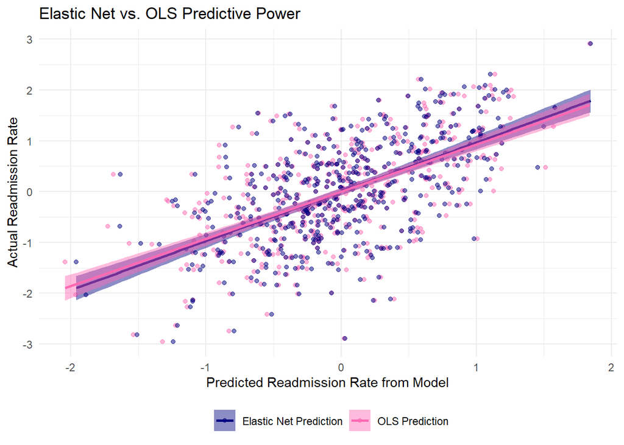

**It should not come as a surprise, but these models are performing VERY similarly!**

#### **Question 32**: [4 points]

What conclusions do you make at this point about whether to make predictions with an OLS regression, Elastic Net, or neither? What recommendations would you make to our client at this point? What other analyses might your suggest, or other data we might want to include? Please try to flesh out 2-3 recommendations in at least a paragraph.

**HINT**: Make sure to ask yourself whether these data appear linear or not. Could non-linearity be a cause for a low $R^2$? If not, what other causes are there and how will that impact your recommendations?

# 7 Choose Your Own Adventure

## Adventure 1.

**[Choosing one other condition to analyze.]**

- Make sure that you use the code I provided, updating it for your new condition
- Make sure to answer all of the interpretative questions again for your new dataset.
- I will specifically be looking for a comparison of which condition, pneumonia or the one you chose, seems to be a better choice for a predictive model for our client. Or is it neither?
- Make sure to include some next steps or recommendations based on your new analysis!

**Recommendations & Hints**:

You can avoid going back to Demo 1 to do your importing, cleaning, and pre-processing by running this source code:

```r
## Make any necessary changes in the R source code
## Uncomment to run!
# source(file = "reRunDemoData.R")
```

- Make sure to update your filepath to where you stored the hospital files on YOUR local machine, just as you did in Question 1 of the Demo!
- Make sure to update the condition that gets selected from “PN” to the condition of your choosing. A full list of available conditions is found in Demo 1.

## Adventure 2.

**[Choosing two or more conditions to analyze.]**

- Choose a slightly more complicated analysis to undertake, for example, focusing on surgical interventions (`HIP-KNEE` & `CABG`) or heart-related conditions (`HF`, `AMI`, & `CABG`).
- See the same recommendations and hints as Adventure 1.

## Adventure 3.

**[Continue analyzing the pneuomnia data.]**

- Make sure to justify your choice.
- Choose at least two new algorithms to perform. They can be unsupervised or supervised, but must be 2+.
- A natural extension would be to do a Ridge and/or a LASSO; the former would tell you if you should be controlling for multicollinearity more than you currently are, the latter would tell you if you need to further shrink coefficients than you currently are. Additionally, you could consider a regression-based method that incorporates **non-linearity**, such as a random forest. However, you are free to choose anything you think is appropriate here!
- Other choices I think you could potentially justify to stakeholders, if you were interested:
1. Switch to classification-based random forest using `ComparedToNational_Hospital return days for pneumonia patients`
2. kNN using the 2 clusters we’ve identified and named in our segmentation analysis
3. Our data are also ready for a neural network analysis (e.g., a feed-forward NN)!

## Deliverables

I am looking for 1-2 markdown documents with their knitted HTML. For example, if you’re choosing Adventures 1 or 2, you may want to work through this document once, make a copy of this markdown document, move the source code to the **TOP**, edit the source code as needed, and then go through this again from the beginning using the new condition(s) you chose.

Alternatively, if you’re choosing Adventure 3, maybe you just choose to add on to the bottom of this document, replacing the ‘Choose Your Own Adventure’ section with your actual adventure.

Just make sure to answer the questions well,and make sure to justify the decisions you make. Tell me WHY you’re choosing the condition(s) you are in Adventures 1 or 2, or Tell me WHY you’re doing the analyses you are in Adventure 3. Other than that, make this your own learning adventure!

## Adventure 3.

**[Continue analyzing the pneuomnia data.]**

## first try a LASSO regression on the dataset, since there is multicolinearity in the predictors.

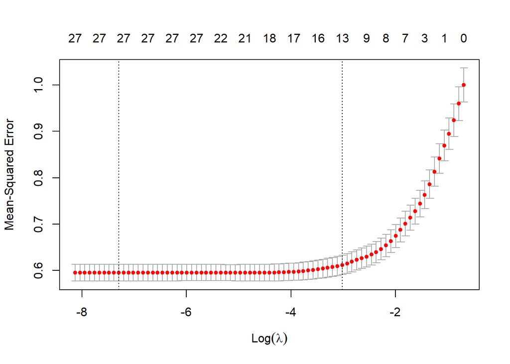

```r
library(glmnet)

load(file = "FY2024_data_files/readyTrain.Rdata")
load(file = "FY2024_data_files/readyTest.Rdata")

# assign the training and test splits
x_train <- model.matrix(bc_PredictedReadmissionRate ~ ., readyTrain)[, -1]
y_train <- readyTrain$bc_PredictedReadmissionRate

# the lasso regression model (alpha=1)
set.seed(465)
glm_model = cv.glmnet(x_train, y_train, alpha=1, nfolds=10)

# find the optimal lambda
lambda.min = glm_model$lambda.min
glm_coef = round(coef(glm_model, s= lambda.min),2)

# plot of test MSE by lambda
plot(glm_model)
```

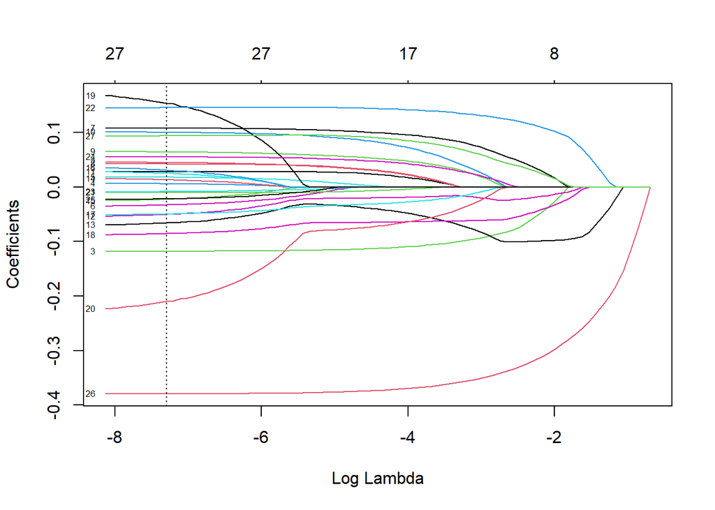

```r
plot(glmnet(x_train, y_train, family="gaussian", alpha=1),"lambd", label=T, main="")
abline(v=log(lambda.min), lty=3)
```

```r
# coefficients of the model
glm_best_model <-glmnet(x_train, y_train, alpha=1, lambda = lambda.min)
coef(glm_best_model)
```

```
## 28 x 1 sparse Matrix of class "dgCMatrix"
##                                                                                    s0
## (Intercept)                                                     0.0000000000000386339
## MRSA.Bacteremia                                                 0.0277814599994804061
## Abdomen.CT.Use.of.Contrast.Material                             0.0447350963435885624
## Death.rate.for.pneumonia.patients                              -0.1180285926583190675
## Postoperative.respiratory.failure.rate                          0.0058842118587933093
## Perioperative.pulmonary.embolism.or.deep.vein.thrombosis.rate   0.0179037908394336573
## Composite.patient.safety                                       -0.0329883947678391715
## Medicare.spending.per.patient                                   0.1078923203284404275
## Healthcare.workers.given.influenza.vaccination                  0.0420678056451970067
## Left.before.being.seen                                          0.0642996152932391596
## Venous.Thromboembolism.Prophylaxis                              0.1003258337398626882
## Nurse.communication                                             0.0257079239686043189
## Doctor.communication                                           -0.0505907977209851256
## Staff.responsiveness                                           -0.0665137050886904502
## Communication.about.medicines                                   0.0135459514134304917
## Discharge.information                                          -0.0229622367557416225
## Care.transition                                                 0.0325499646567450618
## Cleanliness                                                    -0.0494610505394379799
## Quietness                                                      -0.0856251101075083260
## Overall.hospital.rating                                         0.1540486469187158369
## Recommend.hospital                                             -0.2118778259976852596
## SurveyResponseRate                                             -0.0099394925347902809
## PaymentCategory.for.pneumonia.patients                          0.1453615358356294962
## ComparedToNational_MRSA.Bacteremia                             -0.0085211088654801540
## ComparedToNational_Death.rate.for.pneumonia.patients            0.0550772744186075608
## ComparedToNational_Composite.patient.safety                    -0.0218443355770417125
## ComparedToNational_Hospital.return.days.for.pneumonia.patients -0.3794220058525047956
## State                                                           0.0937853740117549350
```

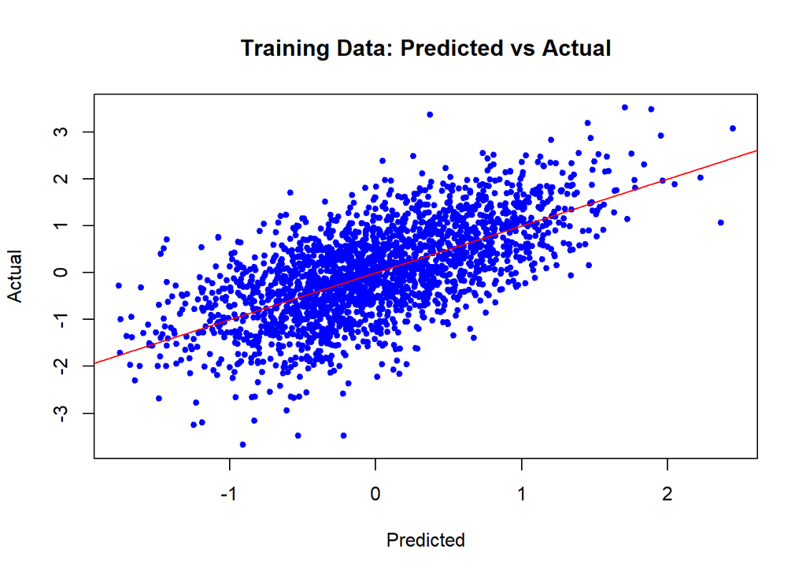

```r
# Make predictions on the training set
predictions_train <- predict(glm_best_model, x_train)

# Make predictions on the test set
#predictions_test <- predict(glm_best_model, y_train)


# prediction vs actual (Training data)
plot(predictions_train, readyTrain$bc_PredictedReadmissionRate, main="Training Data: Predicted vs Actual", xlab="Predicted", ylab="Actual", col='blue', pch=20)
abline(0, 1, col="red")
```

```r
# prediction vs actual (Testing data)
#plot(predictions_test, readyTest$bc_PredictedReadmissionRate, main="Testing Data: Predicted vs Actual", xlab="Predicted", #ylab="Actual", col='blue', pch=20)
#abline(0, 1, col="red")
```